# Advanced ggplot2 Homework

Jerry Balloch

# Question 1.

Take the data in the dataset `qb_revenue_breakdown` and make a stacked bar chart showing the sources of revenue across the two years in the dataset.

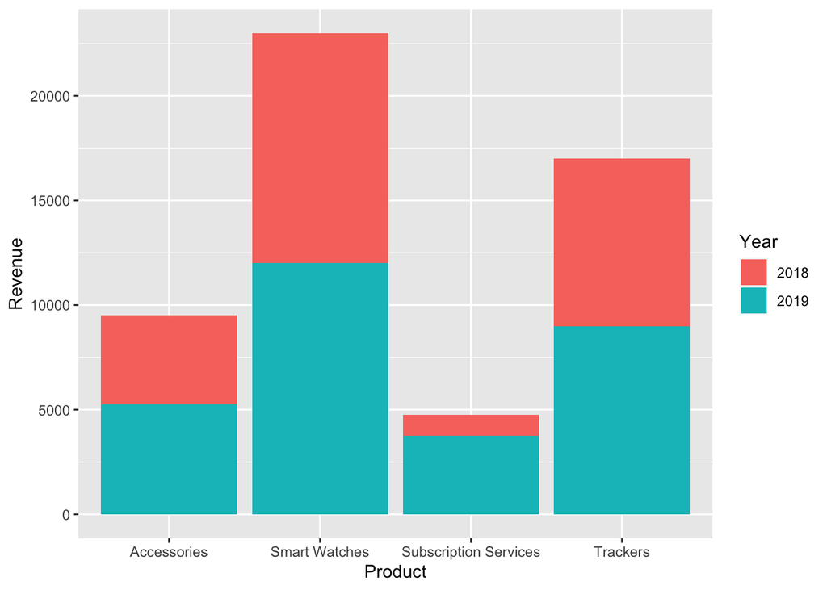

```r
ggplot(qb_revenue_breakdown) +
  aes(x = Product, y = Revenue, fill = Year) +
  geom_bar(position = "stack", stat = "identity")
```

# Question 2.

Make a line chart showing monthly sales of the “flagship product” - the ‘KwikBit Unit 1’ - over the last year. This data is inside `qb_monthly_sales`, but you will need to use `filter()` or `subset()` `(base R)`.

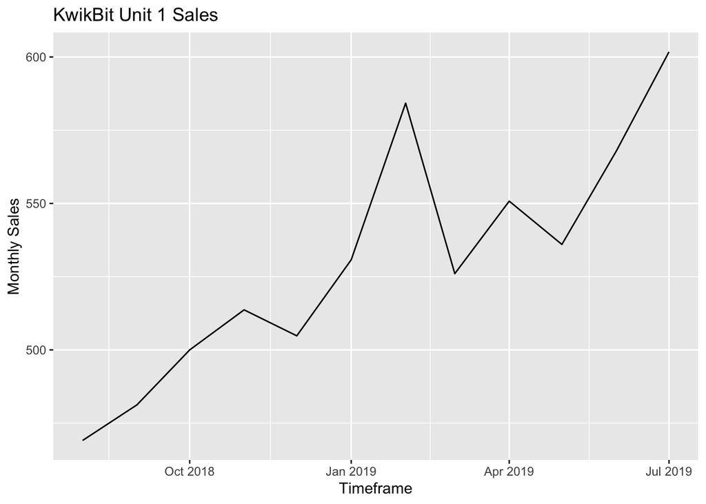

```r
ggplot(qb_monthly_sales %>% filter(Cashflow == "Kwikbit Unit 1 Sales")) +
  aes(x = Date, y = Amount) +
  geom_line() +
  labs(x = "Timeframe",
       y = "Monthly Sales",
       title = "KwikBit Unit 1 Sales")
```

# Question 3.

Make a line chart showing monthly revenue and costs over the last year. This data is also in `qb_monthly_sales`.

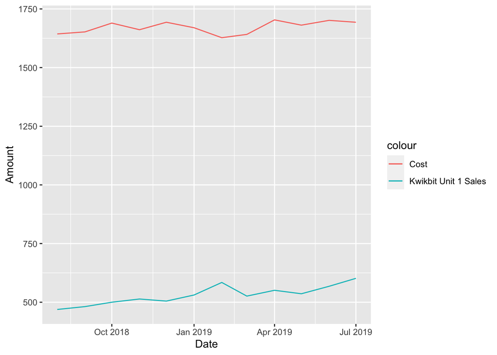

```r
ggplot(qb_monthly_sales) +
  geom_line(aes(x = Date, y = Amount, colour = "Kwikbit Unit 1 Sales"),
            data = qb_monthly_sales %>% filter(Cashflow == "Kwikbit Unit 1 Sales")) +
  geom_line(aes(x = Date, y = Amount, colour = "Cost"),
            data = qb_monthly_sales %>% filter(Cashflow == "Cost"))
```

# Question 4.

Show annual sales of personal fitness trackers over the last 5 years broken down by company as a ribbon plot (use `geom_area`). This data is in `qb_competitors`.

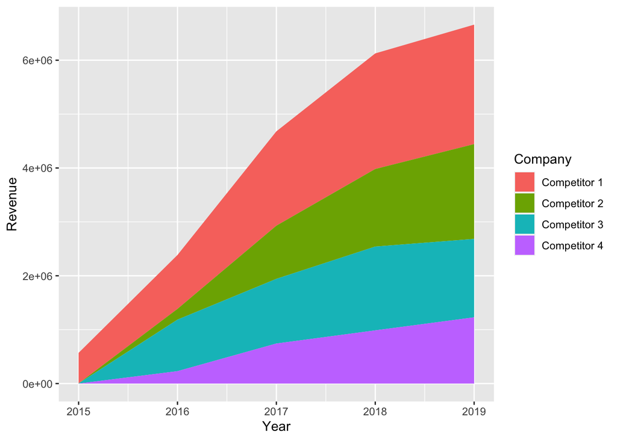

```r
ggplot(qb_competitors) +
  aes(x = Year, y = Revenue, fill = Company) +
  geom_area()
```

# Question 5.

Now show the sales from the four competitors as a line graph. Include an extra layer that shows the data points used to make the lines.

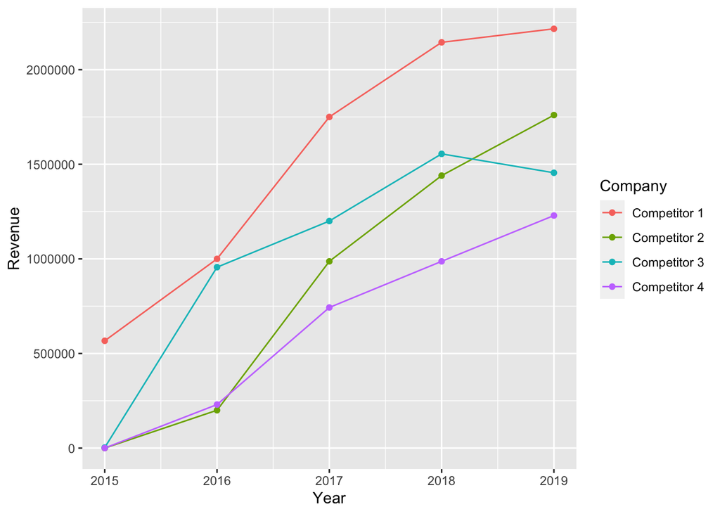

```r
ggplot(qb_competitors) +
  aes(x = Year, y = Revenue, colour = Company) +
  geom_line() +
  geom_point()
```

# Question 6.

Now the company wants to compare the number of steps that their device counts vs. their competitors. Make a line graph of the number of steps throughout time, and use faceting to compare between companies and people. The data for this is in `qb_device_data`.

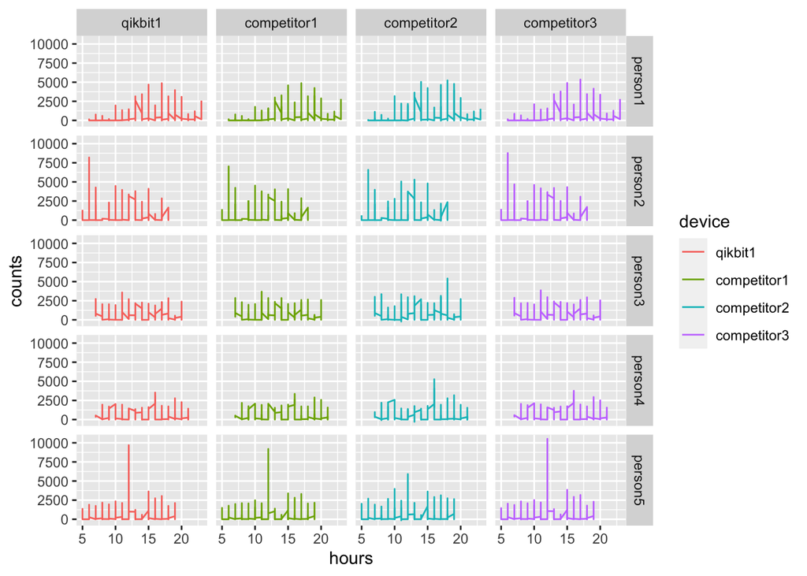

```r
ggplot(qb_device_data) +
  aes(x = hours, y = counts, colour = device) +
  geom_line() +
  facet_grid(id~device)
```